# 5.3 Axe sociopolitique et socioéconomique

Curbcut

# 5.3.2 Pandémie et télétravail

*Source: Statistique Canada, Recensement de la population de 2021.*

La majorité des Lavallois se déplaçaient historiquement vers l’extérieur de la ville pour travailler. Toutefois, entre 2016 et 2021, cette tendance s’est atténuée, la proportion de travailleurs à l’extérieur ayant diminué de 61,8 % à 54,2 %. Autrement dit, on a vu une augmentation historique de Lavallois travaillant sur leur territoire, passant de 38,2 % à 45,8 % sur la même période. Ces changements sont largement attribués à la pandémie de COVID-19, qui a profondément modifié les habitudes de travail en rendant le télétravail plus accessible et répandu. Comme le recensement se base sur le lieu de travail habituel, les Lavallois·es télétravaillant pour des entreprises situées ailleurs, par exemple à Montréal, sont désormais considérés comme travaillant à Laval, ce qui reflète ce changement structurel.

L’année 2021 a été une année charnière pour le télétravail à Laval. Entre 2001 et 2016, le nombre de Lavallois·es travaillant sur place dans leur lieu de travail physique a progressivement diminué, passant de 88,3 % à 85,1 %. Cependant, entre 2016 et 2021, cette diminution s’est accélérée, chutant à 66,3 %. En parallèle, le nombre de personnes travaillant à domicile a fortement augmenté, passant de 5,8 % en 2016 à 22,8 % en 2021. Bien que cette hausse soit en partie liée à la pandémie, elle pourrait annoncer un changement durable dans les pratiques de travail, avec une adoption accrue du télétravail dans les années à venir et modifier les besoins de logements des ménages (par exemple le nombre de chambres à coucher recherchées pour y installer un bureau).

# 5.3.3 Population en résidence pour personnes âgées

_Source:Registre des résidences privées pour aînés (K10). (2024). Ministère de la Santé et des Services sociaux. Récupéré au https://public.arcgis.msss.rtss.qc.ca/arcgis/rest/services/Ressources/K10/MapServer/0_

À Laval, la population des personnes âgées de 75 ans et plus, qui constitue le groupe le plus susceptible de résider en résidence privé pour aînés (RPA), s’élève à 39 265 personnes selon les données du dernier recensement canadien (soit 9,0 % de la population lavalloise et représentant 21 670 ménages, ou 12,8 % des ménages), pour 12 038 places en (RPA), soit un déficit potentiel d’offres de logements en RPA de 27 227 places. La répartition géographique des RPA sur le territoire montre une corrélation modérée avec la population âgée de 75 ans et plus dans chaque district électoral, avec un coefficient de corrélation de 0,78. Cette corrélation positive suggère que, dans une certaine mesure, les districts où l’on trouve plus de personnes âgées sont également ceux où l’on trouve le plus de RPA. Cependant, des disparités persistent.

- Souvenir-Labelle (2 891 places), Vimont (2 000 places), et Laval-des-Rapides (1 830 places) disposent du plus grand nombre de places en RPA, répondant en partie à la demande potentielle, avec respectivement 2 860, 2 545, et 2 650 personnes âgées de 75 ans et plus dans ces quartiers.
- Les districts sans aucune place en RPA, tels que Marc-Aurèle-Fortin, Val-des-Arbres, et Concorde-Bois-de-Boulogne, comptent néanmoins plus de mille résidents âgés chacun (1 860, 1 475, et 1 215 personnes âgées de 75 ans et plus respectivement).

Bien que certains districts semblent disposer d’un nombre suffisant de places en RPA, la répartition géographique de ces places pourrait poser des défis d’accès pour les aînés résidant dans des districts moins bien desservis. Cela pourrait nécessiter des déplacements ou des transferts vers d’autres secteurs de la ville pour recevoir des services appropriés.

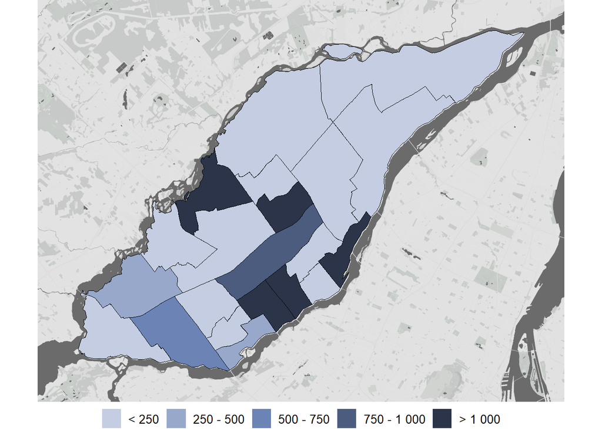

Répartition géographique des places en RPA à travers les différents districts électoraux.

[output not shown]